# ST_5_model

Sean Swift

February 6, 2020

# 1 Description

ST_model focuses on modeling distributions of particular OTUs across the gradient. This often requires subsetting by sample type to better understand changes in abundance. Mostly making linear models.

TODO:

- Try Generalized Additive Models for Location, Scale and Shape (GAMLSS). See https://bmcbioinformatics.biomedcentral.com/articles/10.1186/s12859-019-2744-2 for comparison between GAMLSS and asin(sqrt())
- Make lists of significant, abundant, variable otus and investigate them more thoroughly.
- Finally, with both (1) and this last bit, another useful thing is to relate effect (x) vs. abundance (y) or fit r2 (y) and either color by p or binary black/grey depending on p<0.05. You likely will have to transform the axes to get good spread and a nice “volcano”. But these will help you identify bugs that respond strongly to elevation (effect on x) and are either abundant, fit tightly to elevation, and/or are significant. Wikipedia the volcano plot for some examples, or just google image search it.

# 2 Pick out variable OTUs

Goal: ‘“volcano plot” of -log10(p-value for shore_dist) vs. shore_dist slope or the relative abundance of OTUX to identify a few choice OTUs that are both abundant/change a lot and are highly significant’

## 2.1 Load data

```r
#library(mvabund)
library(ggplot2)
library(dplyr)
library(microbiome)
source("src/make_phyloseq.R")

ST_16S <- readRDS("data/processed/cleaned/ST_16S_spatial.rds")

# make phyloseq
ST_16S_phy <- make_phyloseq(ST_16S)


# get rid of plant shoots
# subset to just include terrestrial samples
# get rid of empty taxa

ST  <- subset_samples(ST_16S_phy, habitat != "Marine")
ST  <- subset_samples(ST, sample_type != "PlantShoot")
ST  <- prune_taxa(taxa_sums(ST) > 0, ST)
```

## 2.2 Set up the models

To get started, define a function that generates linear models (lm) for each otu.

OTUs and values for X are pulled from a phyloseq object. The model coefficients (intercept and slope) and summary coefficients (probablilities, errors, etc.) are stored in a data frame.

Might switch this over to manylm function in mvabund or gamlss for better (more complicated) model fitting.

### 2.2.1 Z score models

```r
# define a function to run linear models, output model coefficients, summary, and relative abundance
# function will also transform both dependent and independent variable to z-scores

get_z_models <- function(physeq, variable = "shore_dist") {
  ## Testing:
   # variable = "shore_dist"
   # physeq = ST
  #
  # pull out variable from sample data
  shore_dist <- physeq@sam_data[[variable]] %>% as.vector
  # transform to z score
  shore_dist_z  <- scale(shore_dist, center = T, scale = T)

  # pull out otu abundances
  abund <- otu_table(physeq) %>%  as.data.frame()

  # apply model to each otu
  probs <- apply(abund, 1, function(x.row) {
          #TESTING:
          #x.row = abund[1200,] %>% unlist()
          # *** MODEL DEFINITION ***
          x.row_z <- scale(x.row)
          mod1 <- lm(x.row_z ~ shore_dist_z)
          ####################################

          sum1 <- summary(mod1)

          append(sum1$coefficients, sum1$r.squared)


          }) %>%
          t() %>%
          as.data.frame()
  # set column names for model outputs
  colnames(probs) <-
  c(
  "intercept",
  "int_err",
  "int_t_value",
  "int_p",
  "slope",
  "slope_err",
  "slope_t_value",
  "slope_p",
  "r.squared"
  )
  # add otu names as a column
  probs$otu <- row.names(abund)
  # add otu relative abundance as a column
  probs$rel_abund <- rowSums(abund)/sum(rowSums(abund))

  # list otu abundance table and model information
  output <- list(probs,abund)
  names(output) <- c("models","abundance")
  return(output)
}
```

### 2.2.2 arcsin square root model

```r
# define a function to run linear models, output model coefficients, summary, and relative abundance
# function will also transform both dependent and independent variable to z-scores

get_arc_models <- function(physeq, variable = "shore_dist") {
  ## Testing:
  #  variable = "shore_dist"
  #  physeq = ST
  #
  # pull out variable from sample data
  shore_dist <- physeq@sam_data[[variable]] %>% as.vector

  # Pull out otu abundance and otu relative abundance (across samples)
  physeq_rel <- transform_sample_counts(physeq, function(x) x / sum(x) )
  abund      <- otu_table(physeq) %>%  as.data.frame()
  rel_abund  <- otu_table(physeq_rel) %>% as.data.frame()
  # apply model to each otu
  probs <- apply(rel_abund, 1, function(x.row) {
          #TESTING:
          # x.row = abund[1200,] %>% unlist()
          # *** MODEL DEFINITION ***
          mod1 <- lm(asin(sqrt(x.row)) ~ shore_dist)
          ####################################

          sum1 <- summary(mod1)

          append(sum1$coefficients, sum1$r.squared)


          }) %>%
          t() %>%
          as.data.frame()
  # set column names for model outputs
  colnames(probs) <-
  c(
  "intercept",
  "int_err",
  "int_t_value",
  "int_p",
  "slope",
  "slope_err",
  "slope_t_value",
  "slope_p",
  "r.squared"
  )
  # add otu names as a column
  probs$otu <- row.names(abund)
  # add otu relative abundance as a column
  probs$rel_abund <- rowSums(abund)/sum(rowSums(abund))

  # list otu abundance table and model information
  output <- list(probs,abund)
  names(output) <- c("models","abundance")
  return(output)
}
```

## 2.3 Linear models : Look for abundant OTUs that change a lot

Having run the model, how many OTUs show up as significantly associated with distance from shore? How many of those OTUs also vary in their abundance (slope of the linear regression)? How many of those OTUs are also highly abundant?

To answer these questions, define functions for two types of “volcano” plots:

*1) p-value of OTU vs. variable slope (usually distance from shore)* *2) p-value of OTU vs. relative abundance of OTU*

```r
# Plot 1: P vs Slope
# define a function to plot p value of otu slope vs the actual slope coefficient
plot_pval_vs_slope <- function(got_models, description)
{
  plot(
    x = got_models$models$slope,
    y = -log10(got_models$models$slope_p),

    main = paste(description, ": P value of model vs. slope coefficient"),
    xlab = "shore_dist slope",
    ylab = "p value (-log10)",

    pch = 1,
    col = "darkblue"
    )
  abline(h = -log10(0.05))
}

# Plot 2: P vs Rel Abund
# define a function to plot p value of otu slope vs the relative abundance of the OTU
plot_pval_vs_RA <- function(got_models, description, physeq)
{
  plot(
    x = got_models$models$rel_abund,
    y = -log10(got_models$models$slope_p),

    main = paste(description, ": P value of model vs. relative abundance of OTU"),
    xlab = "relative abundance of OTU in data",
    ylab = "p value (-log10)",

    pch = 1,
    col = "darkred"
    )
  abline(h=-log10(0.05))
}
```

### 2.3.1 Linear models : All samples

Probably, running these models on all samples together will not be very informative, but let’s try!

```r
# run linear model on all OTUs across all samples (phyloseq object "ST")
p_all_samples_z <- get_z_models(physeq = ST, variable = "shore_dist")
p_all_samples_arc <-get_arc_models(physeq = ST, variable = "shore_dist")


# how many otus have a tiny p value?
length(p_all_samples_z$models$slope_p[  p_all_samples_z$models$slope_p < 0.05  ] )
```

```
## [1] 2892
```

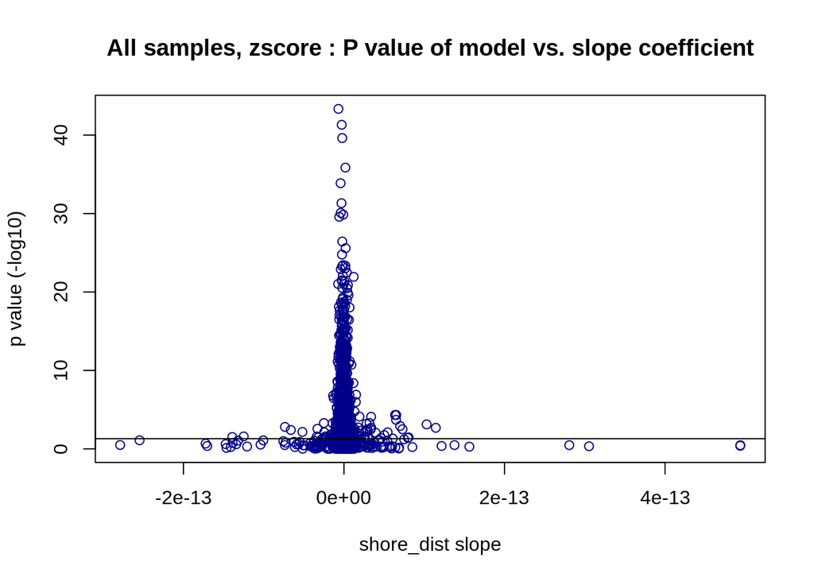

```r
# plot 1
plot_pval_vs_slope(p_all_samples_z, "All samples, zscore")
```

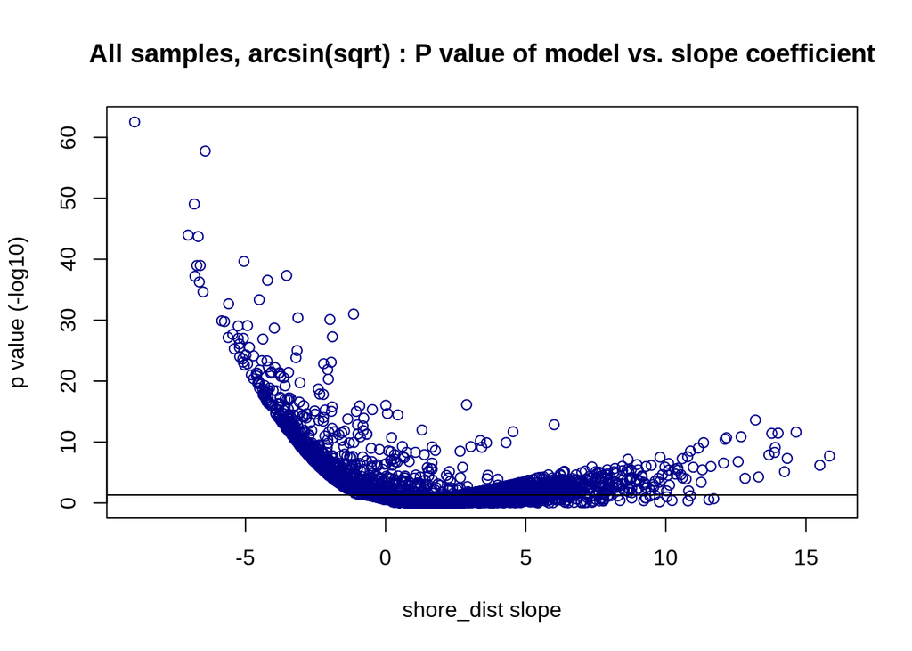

```r
plot_pval_vs_slope(p_all_samples_arc, "All samples, arcsin(sqrt)")
```

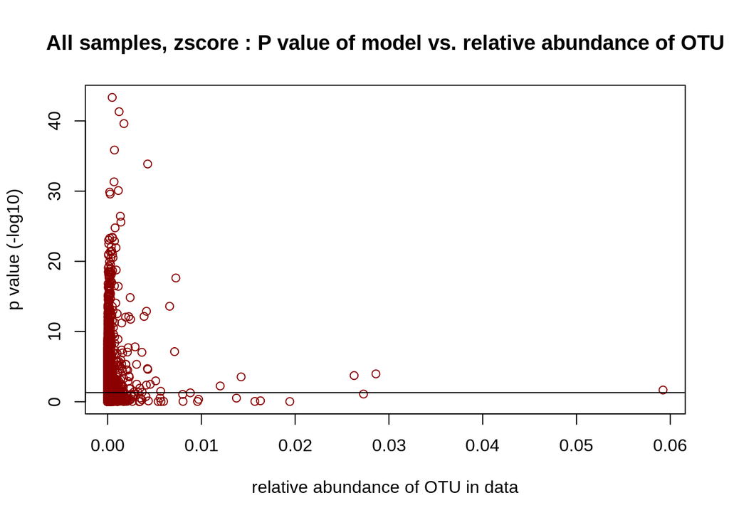

```r
# plot 2
plot_pval_vs_RA(p_all_samples_z, "All samples, zscore")
```

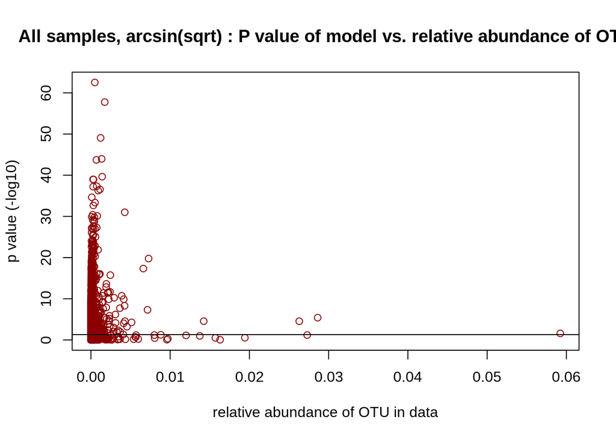

```r
plot_pval_vs_RA(p_all_samples_arc,"All samples, arcsin(sqrt)")
```

### 2.3.2 Linear models : Subset Soil

Soil samples were collected at every transect site. Soil communities appear to vary linearly with the transect gradient. Any good candidate OTUs varying across the gradient?

#### 2.3.2.1 Soil

```r
# All soil samples

# Subset data to just soil samples
ST_soil <- subset_samples(ST, sample_type %in% c( "SoilShallow","SoilDeep"))
ST_soil <- prune_taxa(taxa_sums(ST_soil) > 0, ST_soil)

# run linear model on all OTUs across all samples (phyloseq object "ST")
p_soil_z   <- get_z_models(physeq = ST_soil, variable = "shore_dist")
p_soil_arc <- get_arc_models(physeq = ST_soil, variable = "shore_dist")
rm(ST_soil)

# how many otus have a tiny p value?
length(p_soil_z$models$slope_p[  p_soil_z$models$slope_p < 0.001  ] )
```

```
## [1] 519
```

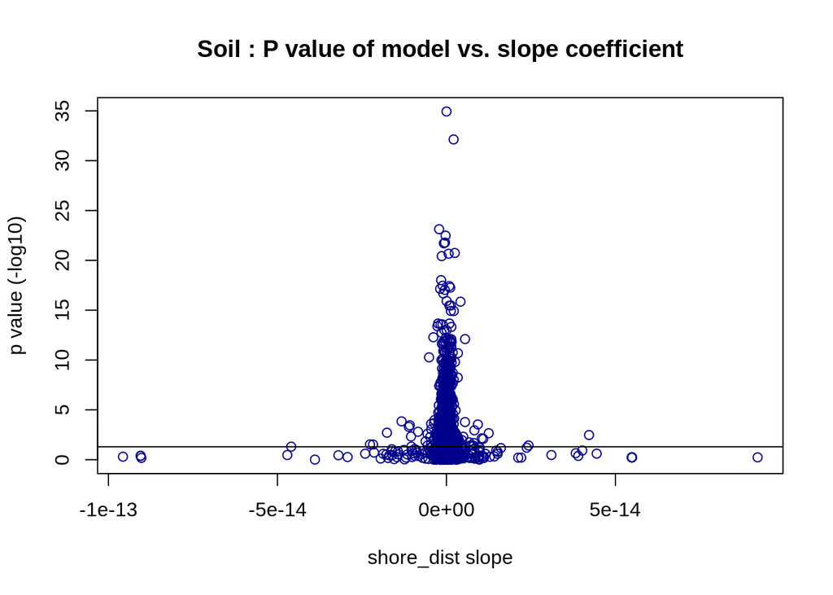

```r
# plot 1
plot_pval_vs_slope(p_soil_z, "Soil")
```

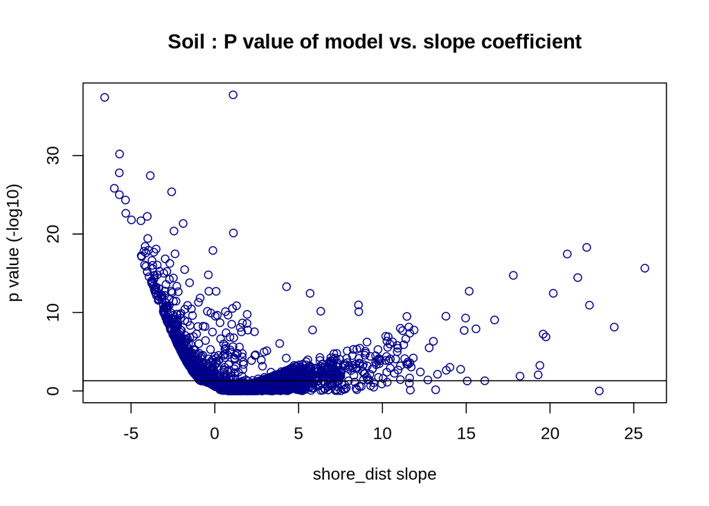

```r
plot_pval_vs_slope(p_soil_arc, "Soil")
```

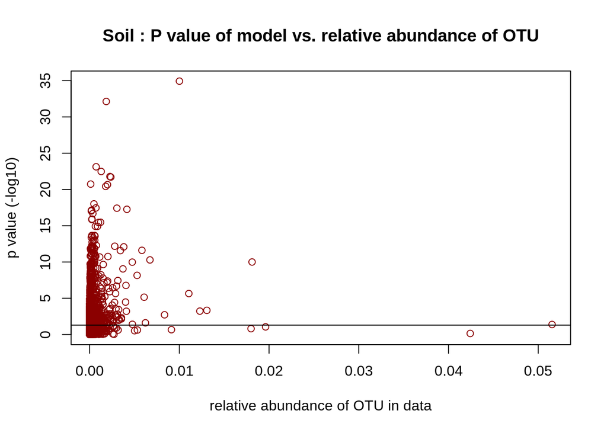

```r
# plot 2
plot_pval_vs_RA(p_soil_z, "Soil")
```

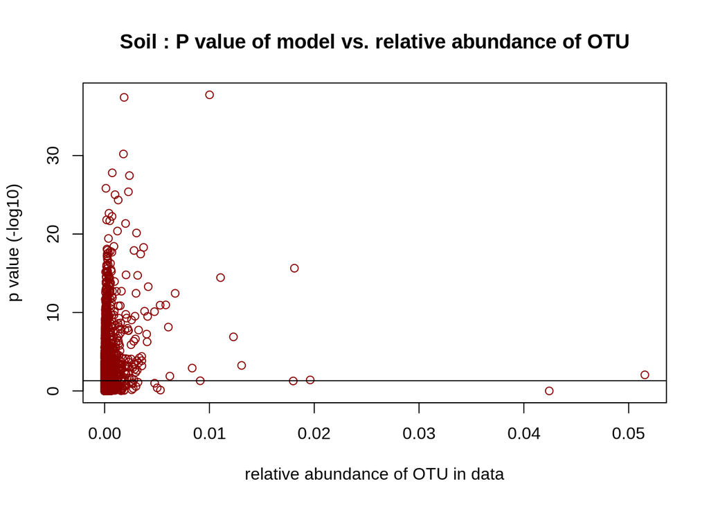

```r
plot_pval_vs_RA(p_soil_arc, "Soil")
```

```r
#####################################

# Shallow Soil Samples

# Subset data to just soil samples
ST_shal_soil <- subset_samples(ST, sample_type %in% c( "SoilShallow"))
ST_shal_soil <- prune_taxa(taxa_sums(ST_shal_soil) > 0, ST_shal_soil)

# run linear model on all OTUs across all samples (phyloseq object "ST")
p_shal_soil_z <- get_z_models(physeq = ST_shal_soil, variable = "shore_dist")
p_shal_soil_arc <- get_arc_models(physeq = ST_shal_soil, variable = "shore_dist")

# how many otus have a tiny p value?
length(p_shal_soil_z$models$slope_p[  p_shal_soil_z$models$slope_p < 0.001  ] )
```

```
## [1] 305
```

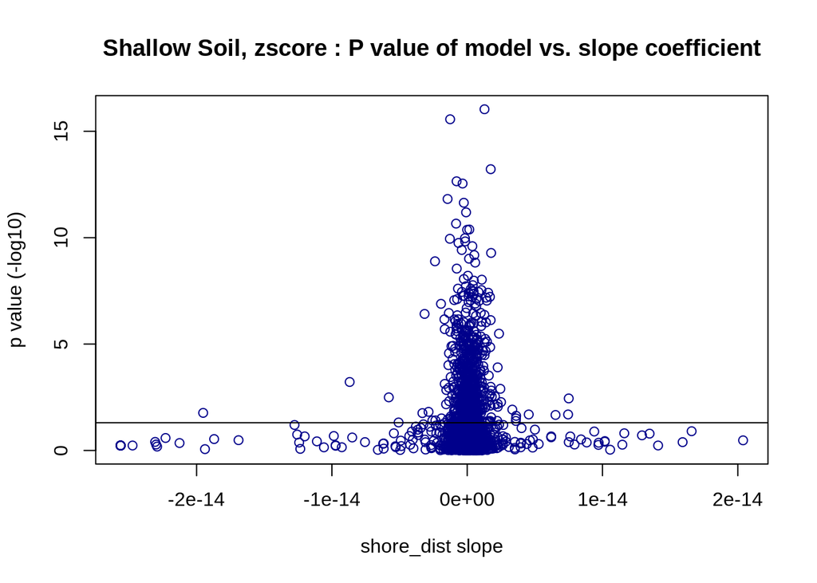

```r
# plot 1
plot_pval_vs_slope(p_shal_soil_z, "Shallow Soil, zscore")
```

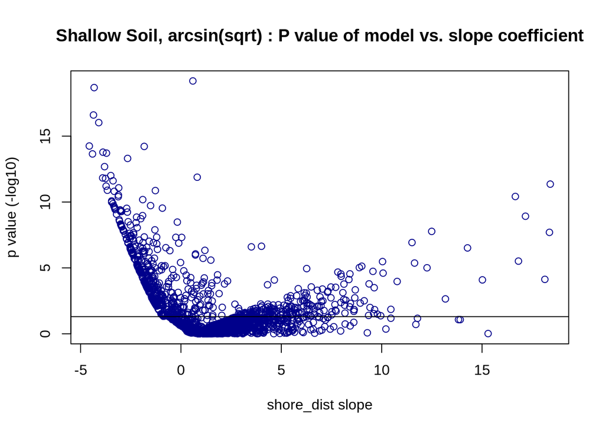

```r
plot_pval_vs_slope(p_shal_soil_arc, "Shallow Soil, arcsin(sqrt)")
```

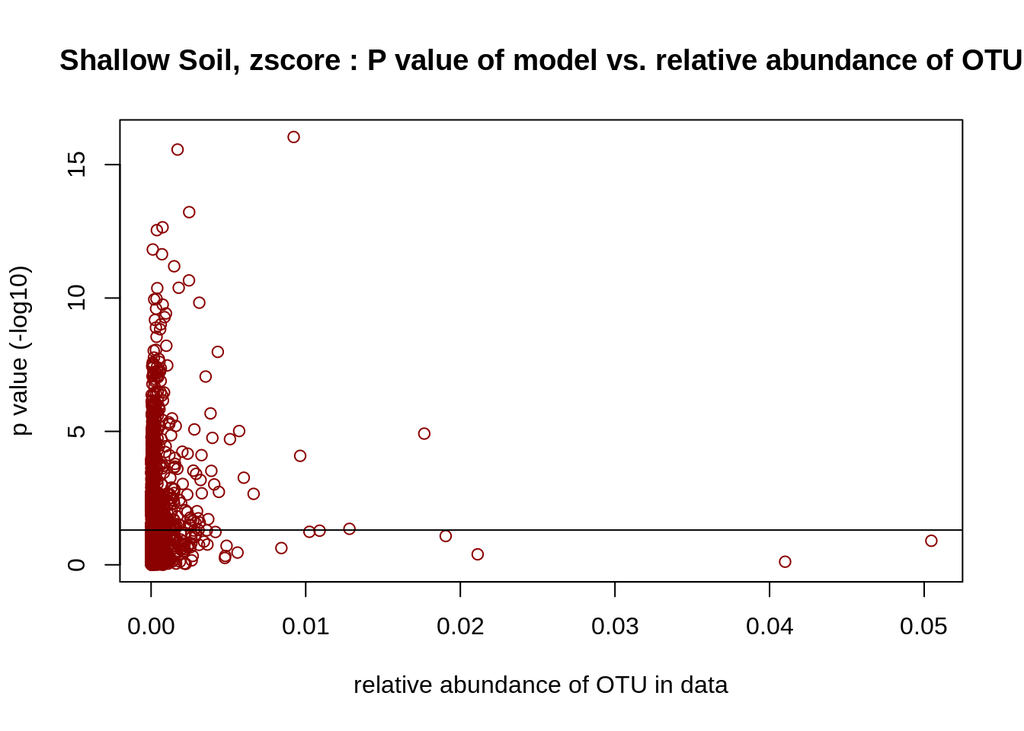

```r
# plot 2
plot_pval_vs_RA(p_shal_soil_z, "Shallow Soil, zscore")
```

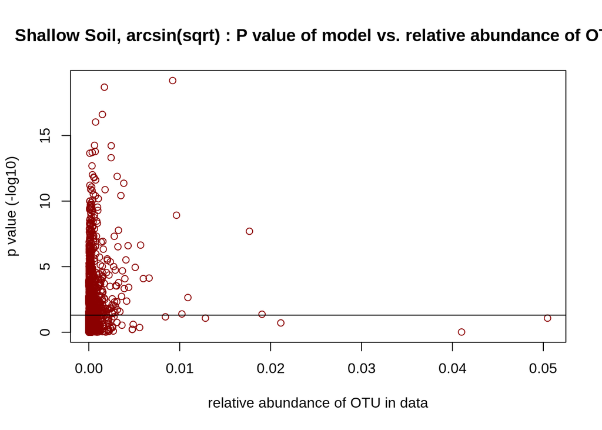

```r
plot_pval_vs_RA(p_shal_soil_arc, "Shallow Soil, arcsin(sqrt)")
```

### 2.3.3 Linear models : Subset Sediment

```r
# Sediment Samples

# Subset data to just soil samples
ST_sed <- subset_samples(ST, sample_type %in% c( "Sediment"))
ST_sed <- prune_taxa(taxa_sums(ST_sed) > 0, ST_sed)

# run linear model on all OTUs across all samples (phyloseq object "ST")
p_sed <- get_z_models(physeq = ST_sed, variable = "shore_dist")

# how many otus have a tiny p value?
length(p_sed$models$slope_p[  p_sed$models$slope_p < 0.001  ] )
```

```
## [1] 226
```

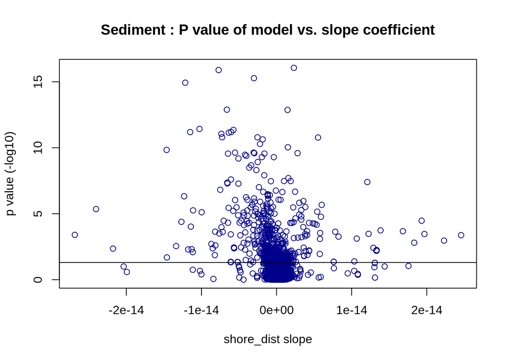

```r
# plot 1
plot_pval_vs_slope(p_sed, "Sediment")
```

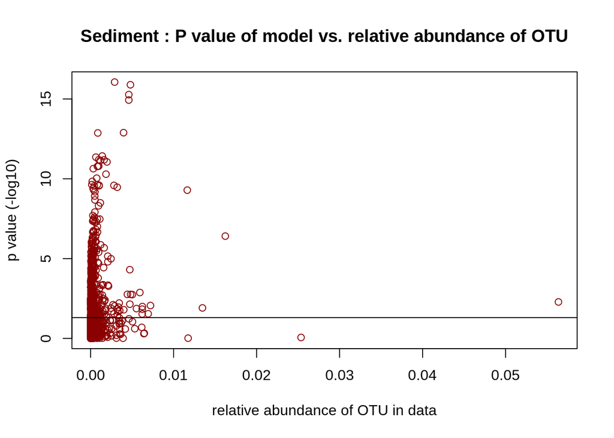

```r
# plot 2
plot_pval_vs_RA(p_sed, "Sediment")
```

### 2.3.4 Linear models : Subset Only Water Samples

Water was collected at all transect sites. Any good candidate OTUs varying across the gradient?

```r
# Subset data to just plant root samples
ST_water <- subset_samples(ST, sample_type %in% c( "WaterNonSaline"))
ST_water <- prune_taxa(taxa_sums(ST_water) > 0, ST_water)

# run linear model on all OTUs across all samples (phyloseq object "ST")
p_water <- get_z_models(physeq = ST_water, variable = "shore_dist")
rm(ST_water)

# how many otus have a tiny p value?
length(p_water$models$slope_p[  p_water$models$slope_p < 0.001  ] )
```

```
## [1] 216
```

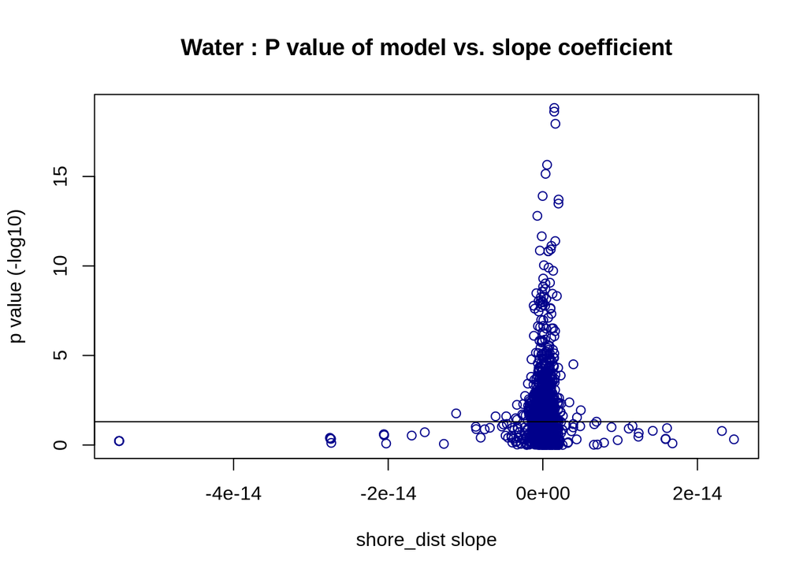

```r
# plot 1
plot_pval_vs_slope(p_water, "Water")
```

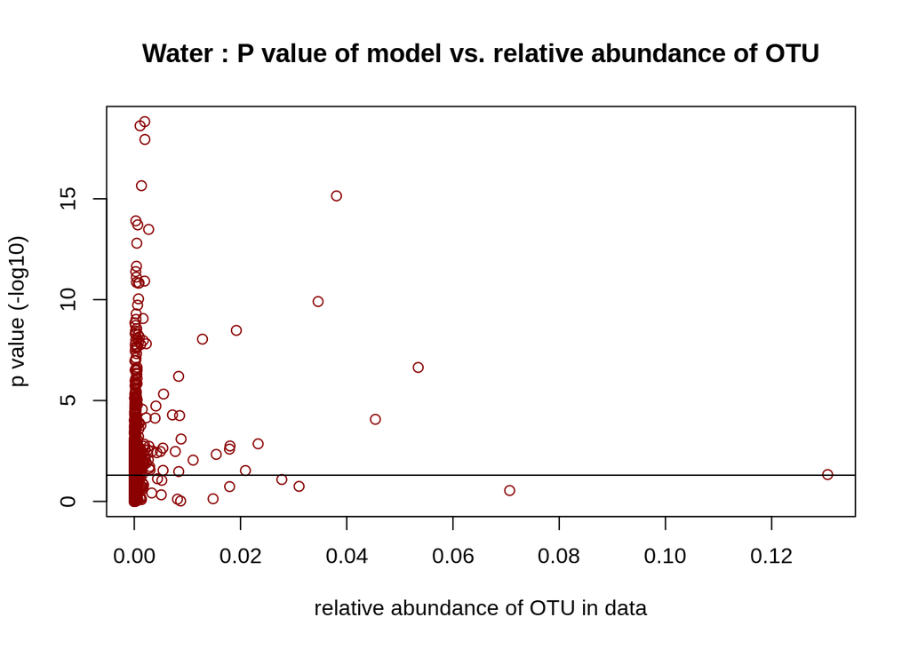

```r
# plot 2
plot_pval_vs_RA(p_water, "Water")
```

### 2.3.5 Linear models : Subset Only Plant Samples

Plant roots were collected at 3 sites per transect. Any good candidate OTUs varying across the gradient?

```r
# Subset data to just plant root samples
ST_plant <- subset_samples(ST, sample_type %in% c( "PlantRoot"))
ST_plant <- prune_taxa(taxa_sums(ST_plant) > 0, ST_plant)

# run linear model on all OTUs across all samples (phyloseq object "ST")
p_plant <- get_z_models(physeq = ST_plant, variable = "shore_dist")
rm(ST_plant)

# how many otus have a tiny p value?
length(p_plant$models$slope_p[  p_plant$models$slope_p < 0.001  ] )
```

```
## [1] 134
```

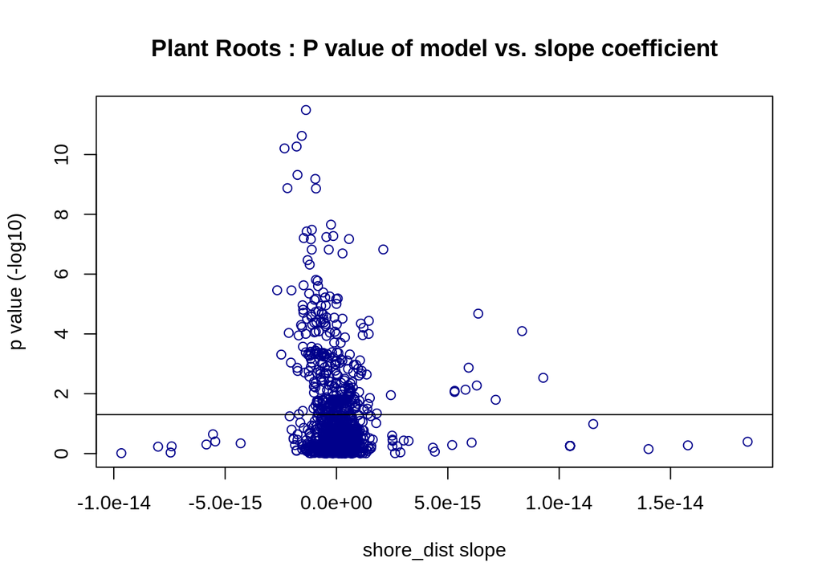

```r
# plot 1
plot_pval_vs_slope(p_plant, "Plant Roots")
```

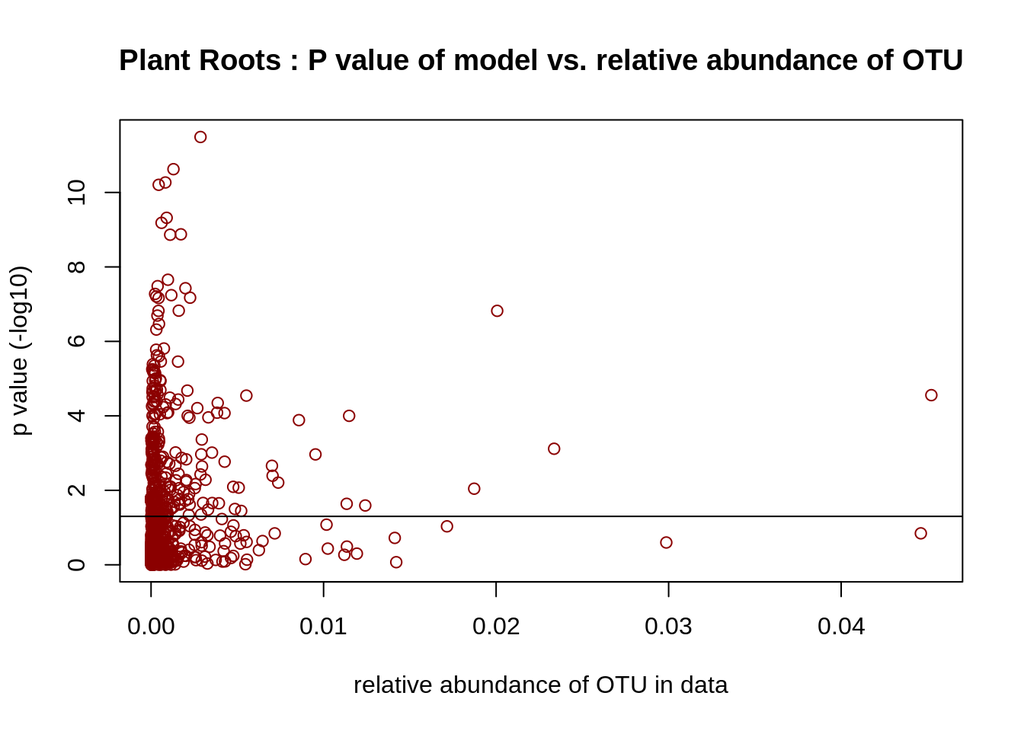

```r
# plot 2
plot_pval_vs_RA(p_plant, "Plant Roots")
```

### 2.3.6 Linear models : Subset Only Mosquito Samples

Mosquitos were collected sort of haphazardly along the transects. Any good candidate OTUs varying across the gradient?

```r
# Subset data to just mosquito samples
ST_mosquito <- subset_samples(ST, sample_type %in% c( "Mosquito"))
ST_mosquito <- prune_taxa(taxa_sums(ST_mosquito) > 0, ST_mosquito)
# run linear model on all OTUs across all samples (phyloseq object "ST")
p_mosquito <- get_z_models(physeq = ST_mosquito, variable = "shore_dist")
rm(ST_mosquito)

# how many otus have a tiny p value?
length(p_mosquito$models$slope_p[  p_mosquito$models$slope_p < 0.001  ] )
```

```
## [1] 0
```

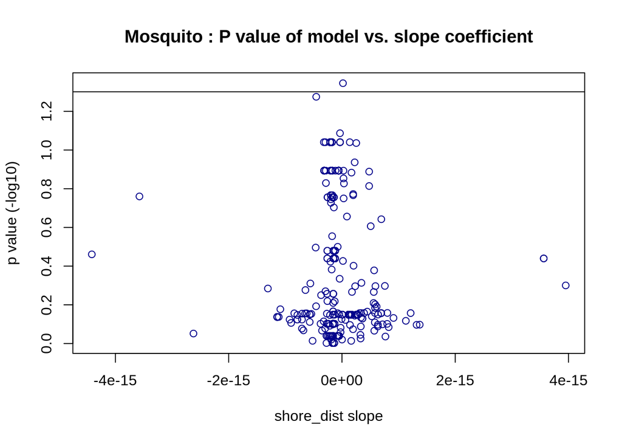

```r
# plot 1
plot_pval_vs_slope(p_mosquito, "Mosquito")
```

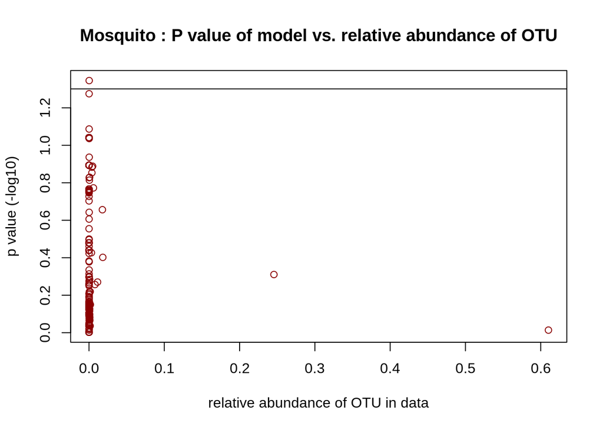

```r
# plot 2
plot_pval_vs_RA(p_mosquito, "Mosquito")
```

### 2.3.7 Linear models : Subset Only Drosophila Samples

Drosophila were collected sort of haphazardly across the transects. Any good candidate OTUs varying across the gradient?

```r
# Subset data to just drosophila samples
ST_drosophila <- subset_samples(ST, sample_type %in% c( "Drosophila"))
ST_drosophila <- prune_taxa(taxa_sums(ST_drosophila) > 0, ST_drosophila)
# run linear model on all OTUs across all samples (phyloseq object "ST")
p_drosophila <- get_z_models(physeq = ST_drosophila, variable = "shore_dist")
rm(ST_drosophila)

# how many otus have a tiny p value?
length(p_drosophila$models$slope_p[  p_drosophila$models$slope_p < 0.001  ] )
```

```
## [1] 2
```

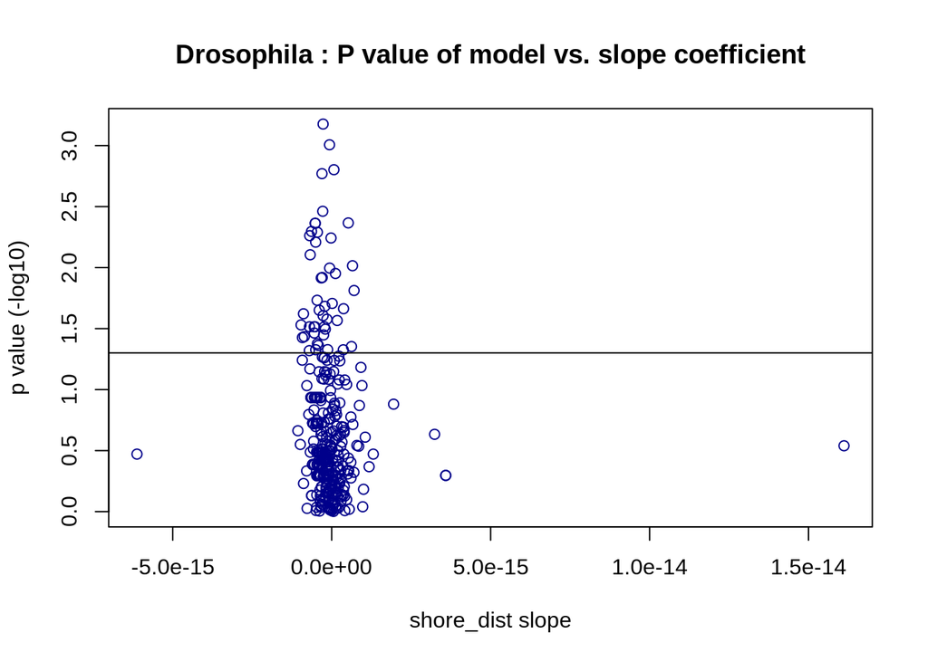

```r
# plot 1
plot_pval_vs_slope(p_drosophila, "Drosophila")
```

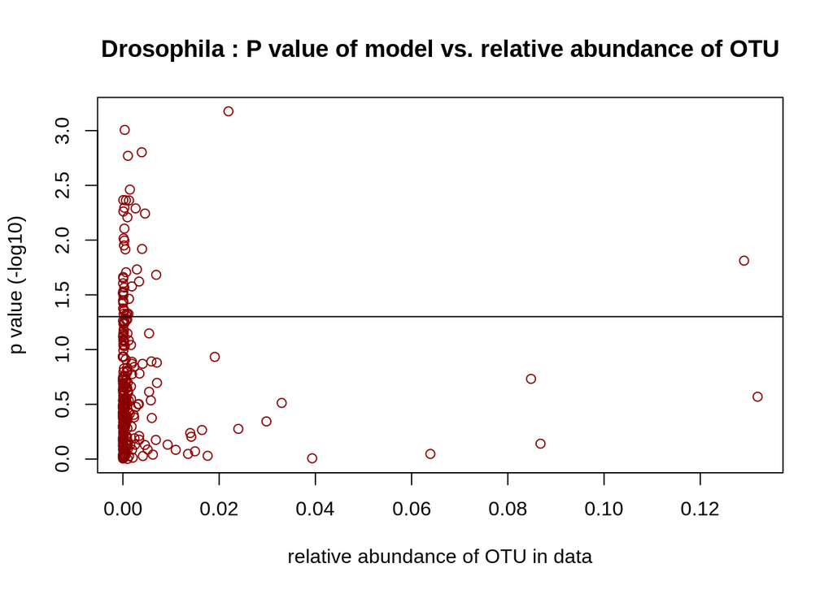

```r
# plot 2
plot_pval_vs_RA(p_drosophila, "Drosophila")
```

## 2.4 Volcano plots

Take the model outputs and make a volcano plot. Effect size (regression coefficient) will be on x axis. Y axis can be relative abundance, or fit. Color points by p value < 0.05

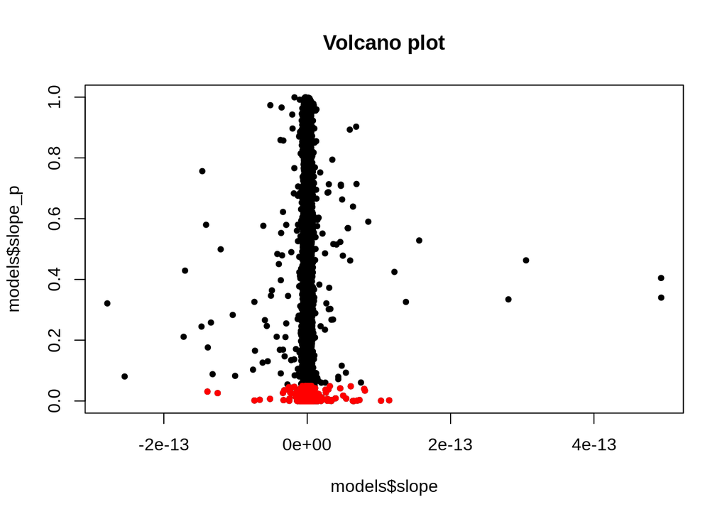

```r
# Make a basic volcano plot
  with(p_all_samples_z, plot(models$slope, models$slope_p, pch=20, main="Volcano plot"))

# Add colored points: red if models$slope_p<0.05, orange of log2FC>1, green if both)
with(subset(p_all_samples_z$models, slope_p<.05 ), points(slope, slope_p, pch=20, col="red"))
```